# TCGA-BRCA DIABLO multi-omics integration: pathological stage

mRNA, protein (RPPA) and DNA methylation

Yueling Peng

2026-10-29

# 1 Overview

This report uses DIABLO (mixOmics `block.splsda`) to integrate three omics layers of TCGA-BRCA and discriminate **pathological stage** (stage i / ii / iii). The model is trained on the training set and then validated on an independent test set.

The inputs are the outputs of the QC pipeline (`scripts/01`–`02`) and the test-set preprocessing (`scripts/04_qc_test.R`):

| Block | Training file | Test file | Values |
| --- | --- | --- | --- |
| mRNA | `rna.train.filtered.rds` | `rna.test.filtered.rds` | log2(CPM + 1) |
| Protein | `prot.train.filtered.rds` | `prot.test.filtered.rds` | RPPA, log2 relative values |
| Methylation | `meth.train.region_M.rds` | `meth.test.region_M.rds` | region-level M-values |

Steps:

1. Read the training set and check the patient order across the three blocks
2. Pre-select features by variance (mRNA 2000, protein 200, methylation 5000)
3. Design matrix, number of components, keepX tuning, final model
4. Result plots
5. Prediction and evaluation on the test set
6. Summary

One rule applies throughout: **every data-driven choice (feature pre-selection, number of components, keepX) is made on the training set only**. The test set is used only for the final evaluation.

# 2 Training data

## 2.1 Read the three blocks

```r
# Step: read the three training blocks
# Input: data/processed/*.train.*.rds
# Output: rna, prot, meth (patient x feature matrices)
rna  <- to_matrix(readRDS(file.path(qc_dir, "rna.train.filtered.rds")))
prot <- to_matrix(readRDS(file.path(qc_dir, "prot.train.filtered.rds")))
meth <- to_matrix(readRDS(file.path(qc_dir, "meth.train.region_M.rds")))
```

## 2.2 Outcome

Stage comes from `outcome_p.stage` in `clin.train.rds`, recoded from the AJCC pathological stage: stage i = i / ia / ib; stage ii = ii / iia / iib; stage iii = iiia / iiib / iiic / iv.

```r
# Step: read the outcome in the same patient order as rna
# Input: clin.train.rds
# Output: Y (factor); print the number of patients per class
clin <- readRDS(file.path(split_dir, "clin.train.rds"))
Y <- factor(clin[rownames(rna), "outcome_p.stage"])
table(Y, useNA = "ifany")
```

```
## Y
##   stage i  stage ii stage iii
##        54       255       127
```

## 2.3 Checks

```r
# Step: check dimensions and patient order
# Input: rna, prot, meth, Y
# Output: print a table
data.frame(check = c("mRNA patients x features", "Protein patients x features",
                     "Methylation patients x features",
                     "Same patient order: mRNA vs protein",
                     "Same patient order: mRNA vs methylation",
                     "Missing outcome values"),
           value = c(paste(dim(rna), collapse = " x "), paste(dim(prot), collapse = " x "),
                     paste(dim(meth), collapse = " x "),
                     all(rownames(rna) == rownames(prot)),
                     all(rownames(rna) == rownames(meth)),
                     sum(is.na(Y))))
```

| check | value |
| --- | --- |
| mRNA patients x features | 436 x 16078 |
| Protein patients x features | 436 x 216 |
| Methylation patients x features | 436 x 61372 |
| Same patient order: mRNA vs protein | TRUE |
| Same patient order: mRNA vs methylation | TRUE |
| Missing outcome values | 0 |

# 3 Feature pre-selection

For each block, the N features with the largest variance are kept. Variance is computed on the training set only and does not use the outcome. Methylation regions with missing values are removed first.

```r
# Step: remove methylation regions with NA
# Input: meth
# Output: meth (no NA); print dimensions
meth <- meth[, colSums(is.na(meth)) == 0]
dim(meth)
```

```
## [1]   436 60639
```

```r
# Step: variance of every feature on the training set
# Input: rna, prot, meth
# Output: rna_var, prot_var, meth_var (named vectors)
rna_var  <- matrixStats::colVars(rna,  useNames = TRUE)
prot_var <- matrixStats::colVars(prot, useNames = TRUE)
meth_var <- matrixStats::colVars(meth, useNames = TRUE)
```

```r
# Step: keep the most variable features of each block as the DIABLO input
# Input: rna, prot, meth and their variances
# Output: X (list of three matrices)
X <- list(mRNA        = rna[,  order(rna_var,  decreasing = TRUE)[1:params$n_genes]],
          protein     = prot[, order(prot_var, decreasing = TRUE)[1:params$n_prot]],
          methylation = meth[, order(meth_var, decreasing = TRUE)[1:params$n_meth]])
data.frame(block = names(X), patients = sapply(X, nrow), features = sapply(X, ncol))
```

|  | block | patients | features |
| --- | --- | --- | --- |
| mRNA | mRNA | 436 | 2000 |
| protein | protein | 436 | 200 |
| methylation | methylation | 436 | 5000 |

Region types among the methylation features (suffix `.promoter` / `.genebody` / `.island`):

```r
# Step: count methylation features by region type
# Input: column names of X$methylation
# Output: print a table
table(sub(".*[.]", "", colnames(X$methylation)))
```

```
##
## genebody   island promoter
##     1102     2871     1027
```

# 4 DIABLO model

## 4.1 Design matrix

The design matrix sets how strongly the blocks are required to correlate with each other. 0.1 is the value recommended by mixOmics; it favours discrimination of the outcome over correlation between blocks.

```r
# Step: 3 x 3 design matrix, 0.1 between blocks, 0 on the diagonal
# Input: names of X
# Output: design
design <- matrix(0.1, nrow = length(X), ncol = length(X), dimnames = list(names(X), names(X)))
diag(design) <- 0
design
```

```
##             mRNA protein methylation
## mRNA         0.0     0.1         0.1
## protein      0.1     0.0         0.1
## methylation  0.1     0.1         0.0
```

## 4.2 Number of components

A 5-component model without feature selection is fitted first. The number of components is chosen by 5-fold cross-validation repeated 5 times, as the one with the lowest balanced error rate (BER) under weighted vote and centroids distance. This takes 1–2 minutes.

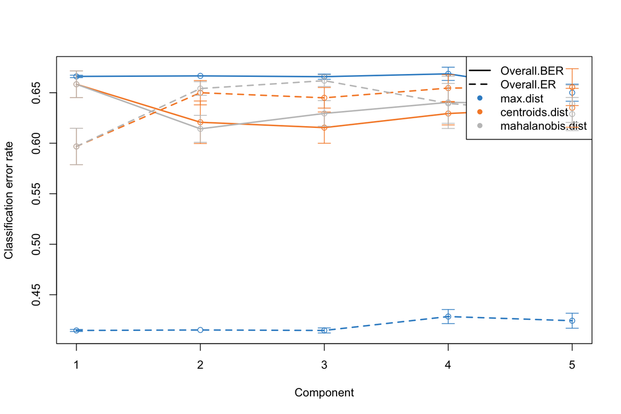

```r
# Step: initial model without feature selection, plus cross-validation
# Input: X, Y, design
# Output: perf_init (error rates per number of components)
diablo_init <- block.plsda(X, Y, ncomp = 5, design = design)
perf_init <- perf(diablo_init, validation = "Mfold", folds = 5, nrepeat = 5,
                  BPPARAM = BiocParallel::MulticoreParam(n_cores), seed = params$seed)
plot(perf_init)
```

```r
# Step: choose the number of components by BER (centroids distance)
# Input: perf_init
# Output: ncomp; print the number of components suggested for each distance
perf_init$choice.ncomp$WeightedVote
```

```
##             max.dist centroids.dist mahalanobis.dist
## Overall.ER         1              1                1
## Overall.BER        5              2                2
```

```r
ncomp <- perf_init$choice.ncomp$WeightedVote["Overall.BER", "centroids.dist"]
ncomp
```

```
## [1] 2
```

## 4.3 Tuning keepX

For each block, several numbers of features per component are tested, and the combination with the lowest BER in 5-fold cross-validation (5 repeats) is kept. There are 4 × 4 × 4 = 64 combinations; this takes a few minutes. The message “Design matrix has changed to include Y” is expected and is not an error.

```r
# Step: tune keepX by cross-validation
# Input: X, Y, design, ncomp
# Output: tune; print the selected keepX
test_keepX <- list(mRNA        = c(10, 25, 50, 100),
                   protein     = c(5, 10, 20, 40),
                   methylation = c(10, 25, 50, 100))
tune <- tune.block.splsda(X, Y, ncomp = ncomp, test.keepX = test_keepX, design = design,
                          validation = "Mfold", folds = 5, nrepeat = 5, dist = "centroids.dist",
                          BPPARAM = BiocParallel::MulticoreParam(n_cores), seed = params$seed)
tune$choice.keepX
```

```
## $mRNA
## [1]  50 100
##
## $protein
## [1]  5 40
##
## $methylation
## [1]  25 100
```

## 4.4 Final model

```r
# Step: fit the final model with the selected ncomp and keepX
# Input: X, Y, design, ncomp, tune$choice.keepX
# Output: diablo (block.splsda model)
diablo <- block.splsda(X, Y, ncomp = ncomp, keepX = tune$choice.keepX, design = design)
diablo
```

```
##
## Call:
##  block.splsda(X = X, Y = Y, ncomp = ncomp, keepX = tune$choice.keepX, design = design)
##
##  sGCCA with 2 components on block 1 named mRNA
##  sGCCA with 2 components on block 2 named protein
##  sGCCA with 2 components on block 3 named methylation
##  sGCCA with 2 components on the outcome Y
##
##  Dimension of block 1 is  436 2000
##  Dimension of block 2 is  436 200
##  Dimension of block 3 is  436 5000
##  Outcome Y has 3 levels
##
##  Selection of 50 100 variables on each of the sGCCA components on the block 1
##  Selection of 5 40 variables on each of the sGCCA components on the block 2
##  Selection of 25 100 variables on each of the sGCCA components on the block 3
##
##  Main numerical outputs:
##  --------------------
##  loading vectors: see object$loadings
##  variates: see object$variates
##  variable names: see object$names
##
##  Functions to visualise samples:
##  --------------------
##  plotIndiv, plotArrow, cimDiablo, plotDiablo
##
##  Functions to visualise variables:
##  --------------------
##  plotVar, plotLoadings, network, circosPlot
##
##  Other functions:
##  --------------------
##  selectVar, perf, auc
```

```r
# Step: cross-validated error rates of the final model (training set)
# Input: diablo
# Output: perf_final; print error rates under weighted vote and centroids distance
perf_final <- perf(diablo, validation = "Mfold", folds = 5, nrepeat = 5, dist = "centroids.dist",
                   BPPARAM = BiocParallel::MulticoreParam(n_cores), seed = params$seed)
perf_final$WeightedVote.error.rate$centroids.dist
```

```
##                 comp1     comp2
## stage i     0.9111111 0.5740741
## stage ii    0.6619608 0.7058824
## stage iii   0.3700787 0.5858268
## Overall.ER  0.6077982 0.6545872
## Overall.BER 0.6477169 0.6219277
```

# 5 Result plots

Correlation between the first components of the three blocks, and the distribution of patients on each block’s component:

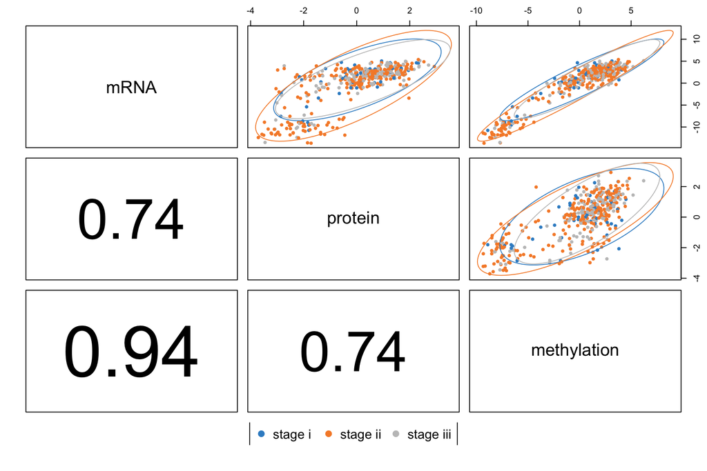

```r
# Step: DIABLO correlation plot (component 1)
# Input: diablo
# Output: plot
plotDiablo(diablo, ncomp = 1)
```

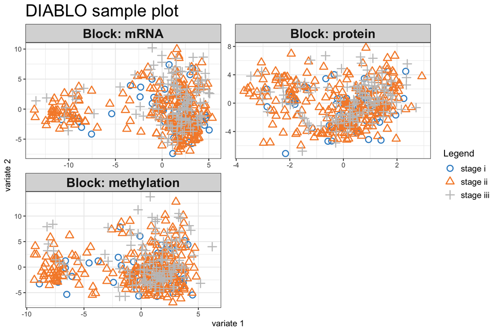

```r
# Step: sample plot (component 1 vs 2), coloured by stage
# Input: diablo
# Output: plot
plotIndiv(diablo, ind.names = FALSE, legend = TRUE, title = "DIABLO sample plot")
```

Correlations between selected features across blocks (lines drawn only for |r| > 0.7):

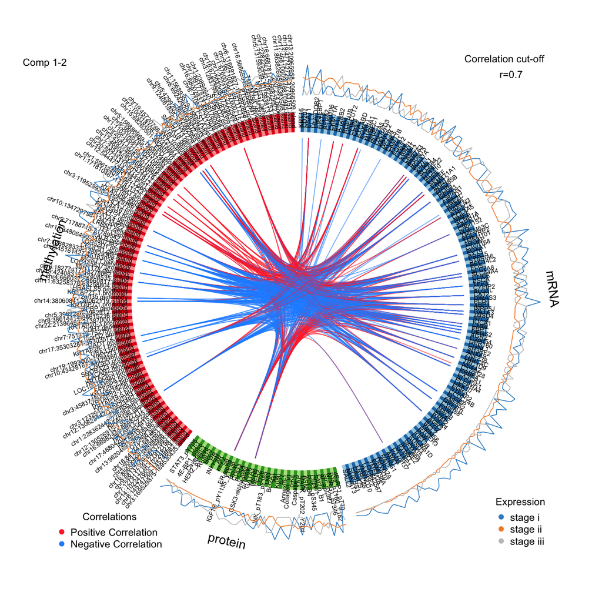

```
##
## adding block name to feature names in the output similarity matrix as there are similar feature names across blocks.
```

```r
# Step: circos plot
# Input: diablo
# Output: plot
circosPlot(diablo, cutoff = 0.7, line = TRUE, size.variables = 0.5)
```

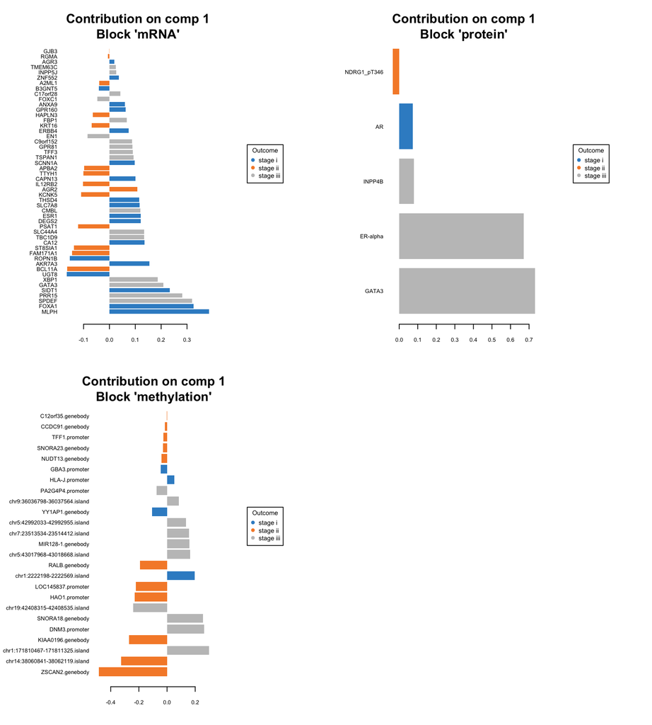

```r
# Step: loading plot for component 1 (coloured by the class with the largest median)
# Input: diablo
# Output: plot
plotLoadings(diablo, comp = 1, contrib = "max", method = "median")
```

Top features on component 1 in each block (largest absolute loadings):

```r
# Step: 10 features with the largest absolute loading on component 1, per block
# Input: diablo$loadings
# Output: print a table
do.call(rbind, lapply(names(X), function(block) {
  L <- diablo$loadings[[block]][, 1]
  L <- L[L != 0]
  top <- head(L[order(abs(L), decreasing = TRUE)], 10)
  data.frame(block = block, feature = names(top), loading = round(unname(top), 3))
}))
```

| block | feature | loading |
| --- | --- | --- |
| mRNA | MLPH | 0.385 |
| mRNA | FOXA1 | 0.326 |
| mRNA | SPDEF | 0.320 |
| mRNA | PRR15 | 0.281 |
| mRNA | SIDT1 | 0.234 |
| mRNA | GATA3 | 0.209 |
| mRNA | XBP1 | 0.187 |
| mRNA | UGT8 | -0.164 |
| mRNA | BCL11A | -0.164 |
| mRNA | AKR7A3 | 0.155 |
| protein | GATA3 | 0.732 |
| protein | ER-alpha | 0.672 |
| protein | INPP4B | 0.079 |
| protein | AR | 0.072 |
| protein | NDRG1_pT346 | -0.034 |
| methylation | ZSCAN2.genebody | -0.485 |
| methylation | chr14:38060841-38062119.island | -0.327 |
| methylation | chr1:171810467-171811325.island | 0.298 |
| methylation | KIAA0196.genebody | -0.271 |
| methylation | DNM3.promoter | 0.264 |
| methylation | SNORA18.genebody | 0.255 |
| methylation | chr19:42408315-42408535.island | -0.242 |
| methylation | HAO1.promoter | -0.231 |
| methylation | LOC145837.promoter | -0.221 |
| methylation | chr1:2222198-2222569.island | 0.195 |

# 6 Test set validation

The test set (`scripts/04_qc_test.R`) was processed with all QC parameters learned on the training set. Here only the features used in training are taken.

```r
# Step: read the test set, keep the training features and patients present in all three blocks
# Input: data/processed/*.test.*.rds, X
# Output: X_test (list)
rna_test  <- to_matrix(readRDS(file.path(qc_dir, "rna.test.filtered.rds")))
prot_test <- to_matrix(readRDS(file.path(qc_dir, "prot.test.filtered.rds")))
meth_test <- to_matrix(readRDS(file.path(qc_dir, "meth.test.region_M.rds")))
patients_test <- Reduce(intersect, list(rownames(rna_test), rownames(prot_test), rownames(meth_test)))
X_test <- list(mRNA        = rna_test[patients_test,  colnames(X$mRNA)],
               protein     = prot_test[patients_test, colnames(X$protein)],
               methylation = meth_test[patients_test, colnames(X$methylation)])
```

```r
# Step: dimensions and missing values of the test set
# Input: X_test
# Output: print a table
data.frame(block = names(X_test), patients = sapply(X_test, nrow),
           features = sapply(X_test, ncol), missing_values = sapply(X_test, function(x) sum(is.na(x))))
```

|  | block | patients | features | missing_values |
| --- | --- | --- | --- | --- |
| mRNA | mRNA | 187 | 2000 | 0 |
| protein | protein | 187 | 200 | 0 |
| methylation | methylation | 187 | 5000 | 34 |

```r
# Step: true stage of the test patients (same levels as training)
# Input: clin.test.rds
# Output: Y_test; print the number of patients per class
clin_test <- readRDS(file.path(split_dir, "clin.test.rds"))
Y_test <- factor(clin_test[patients_test, "outcome_p.stage"], levels = levels(Y))
table(Y_test, useNA = "ifany")
```

```
## Y_test
##   stage i  stage ii stage iii
##        30       105        52
```

Prediction uses the same settings as the cross-validation: weighted vote and centroids distance.

```r
# Step: predict the test set
# Input: diablo, X_test
# Output: pred; pred_class (patient x component predicted classes)
pred <- predict(diablo, newdata = X_test, dist = "centroids.dist")
pred_class <- pred$WeightedVote$centroids.dist
```

```r
# Step: BER on the test set vs training cross-validation, per number of components
# Input: pred_class, Y_test, perf_final
# Output: print a table
test_ber <- apply(pred_class, 2, function(p) get.BER(get.confusion_matrix(truth = Y_test, predicted = p)))
data.frame(component = seq_len(ncomp),
           train_cv_BER = perf_final$WeightedVote.error.rate$centroids.dist["Overall.BER", ],
           test_BER = test_ber)
```

|  | component | train_cv_BER | test_BER |
| --- | --- | --- | --- |
| comp1 | 1 | 0.6477169 | 0.6070818 |
| comp2 | 2 | 0.6219277 | 0.5508547 |

Confusion matrix with the final number of components (rows = true class, columns = predicted class):

```r
# Step: confusion matrix
# Input: last column of pred_class, Y_test
# Output: print the confusion matrix
get.confusion_matrix(truth = Y_test, predicted = pred_class[, ncomp])
```

```
##           predicted.as.stage i predicted.as.stage ii predicted.as.stage iii
## stage i                     16                     7                      7
## stage ii                    30                    35                     40
## stage iii                   21                     6                     25
```

# 7 Summary

```r
# Step: main results
# Input: Y, Y_test, ncomp, perf_final, test_ber, pred_class
# Output: print a table
chance_ber    <- 1 - 1 / nlevels(Y)
train_ber     <- perf_final$WeightedVote.error.rate$centroids.dist["Overall.BER", ncomp]
test_accuracy <- mean(pred_class[, ncomp] == Y_test)
majority_rate <- max(table(Y_test)) / length(Y_test)
data.frame(item = c("Training patients", "Test patients", "Components",
                    "Train CV BER (final component)", "Test BER (final component)",
                    "Chance-level BER (3 classes)", "Test accuracy (final component)",
                    "Accuracy of always predicting the largest class"),
           value = as.character(c(length(Y), length(Y_test), ncomp,
                                  round(train_ber, 3), round(test_ber[ncomp], 3), round(chance_ber, 3),
                                  round(test_accuracy, 3), round(majority_rate, 3))))
```

| item | value |
| --- | --- |
| Training patients | 436 |
| Test patients | 187 |
| Components | 2 |
| Train CV BER (final component) | 0.622 |
| Test BER (final component) | 0.551 |
| Chance-level BER (3 classes) | 0.667 |
| Test accuracy (final component) | 0.406 |
| Accuracy of always predicting the largest class | 0.561 |

**Model.** DIABLO integrated 2000 mRNA genes, 200 proteins and 5000 methylation regions from 436 training patients. Cross-validation selected 2 components and kept 320 features in total (mRNA 150, protein 45, methylation 125).

**Performance.** The balanced error rate was 0.622 in training cross-validation and 0.551 on the 187 test patients, against a chance level of 0.667 for three classes. The model is only slightly better than chance: **pathological stage cannot be reliably predicted from these molecular profiles**. The overall test accuracy (0.406) is even lower than always predicting the largest class, stage ii (0.561), because the model is tuned on BER and spreads its predictions over all three classes. The test BER is close to the cross-validation BER, so the model does not overfit; the signal for stage is simply weak.

**Biology.** Component 1 is driven by the luminal programme: ER-alpha and GATA3 in the protein block, and FOXA1, MLPH and SPDEF in the mRNA block. This axis separates luminal from basal-like tumours, i.e. it reflects molecular subtype rather than stage. This fits the known biology: stage is defined by tumour size, lymph-node involvement and metastasis (TNM), which depend mainly on how long the tumour has grown and when it was detected, not on a distinct expression or methylation profile of the bulk tumour.

**Limitations.**

- The classes are imbalanced (stage ii is the largest), which limits the accuracy for stage i and iii.
- Stage iv patients are merged into stage iii, and stage substages (e.g. iia vs iib) are not modelled.
- Features were pre-selected by variance without using the outcome, so features weakly related to stage but with low variance may have been removed.

**Conclusion.** The data and pipeline work as intended (consistent performance between cross-validation and test set, no leakage from test to training), but pathological stage is not a suitable outcome for molecular discrimination in TCGA-BRCA. Molecular subtype (e.g. PAM50) or survival-related endpoints are more suitable targets for DIABLO.